# Birthweights 1914 - 1922

# Birth weights

## Time series

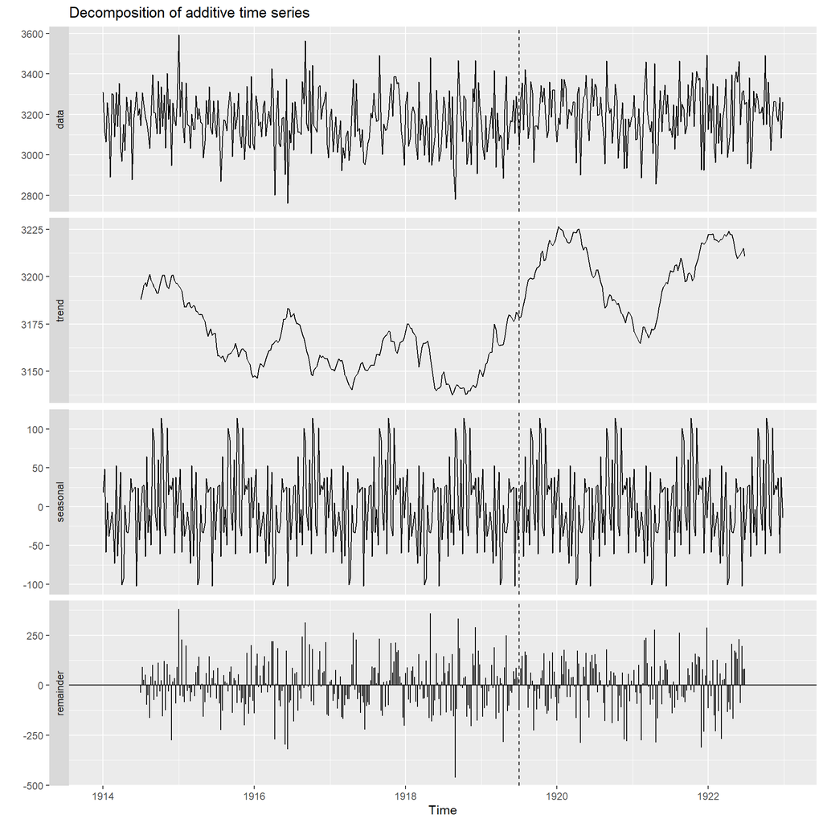

Gestational age, the differences are minimal (range: 39.6 - 40 weeks), there is no breakpoint.

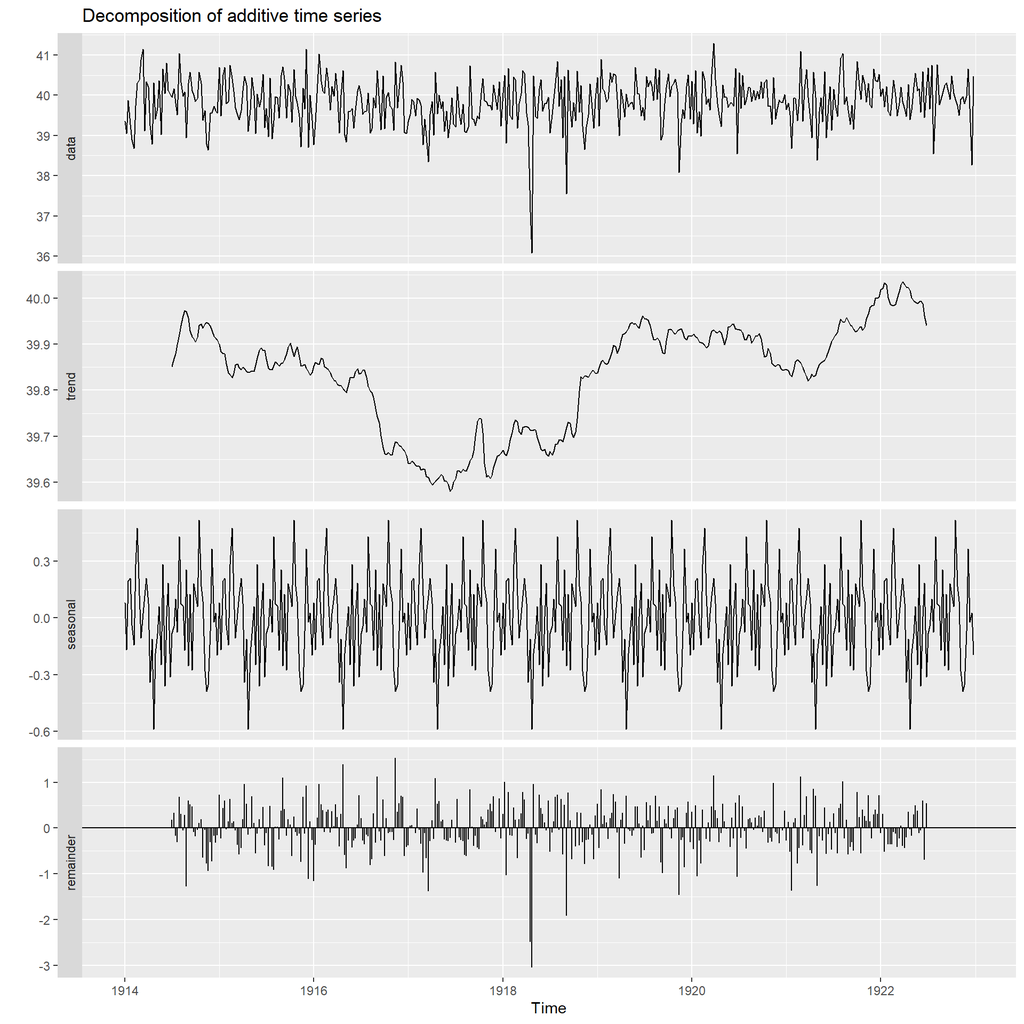

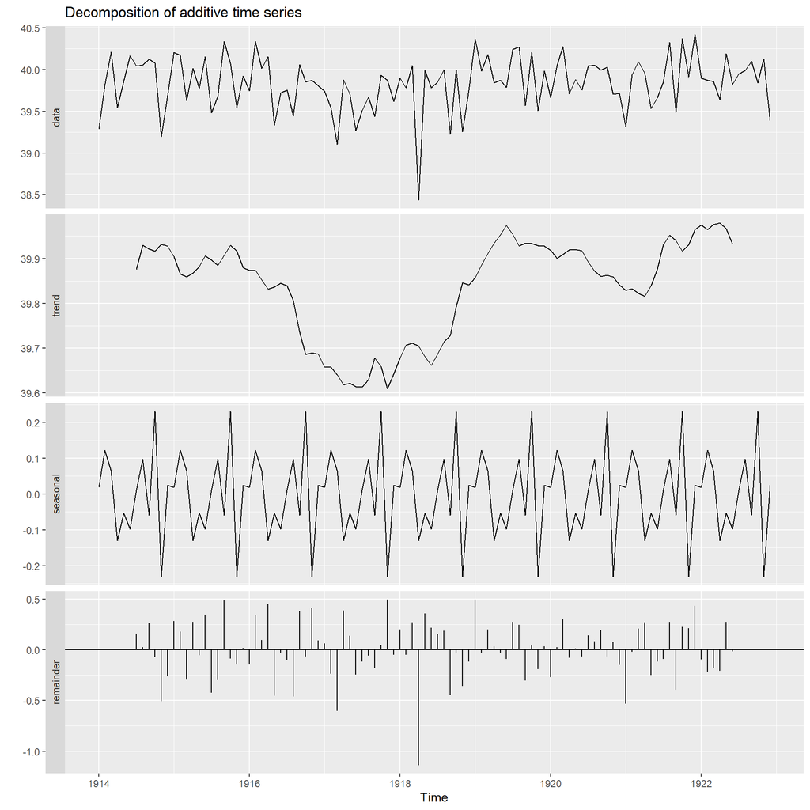

Stillborn = (sum of stillborn per week/sum birth per week) *100, no breakpoint, but more stillborns 1918/1919

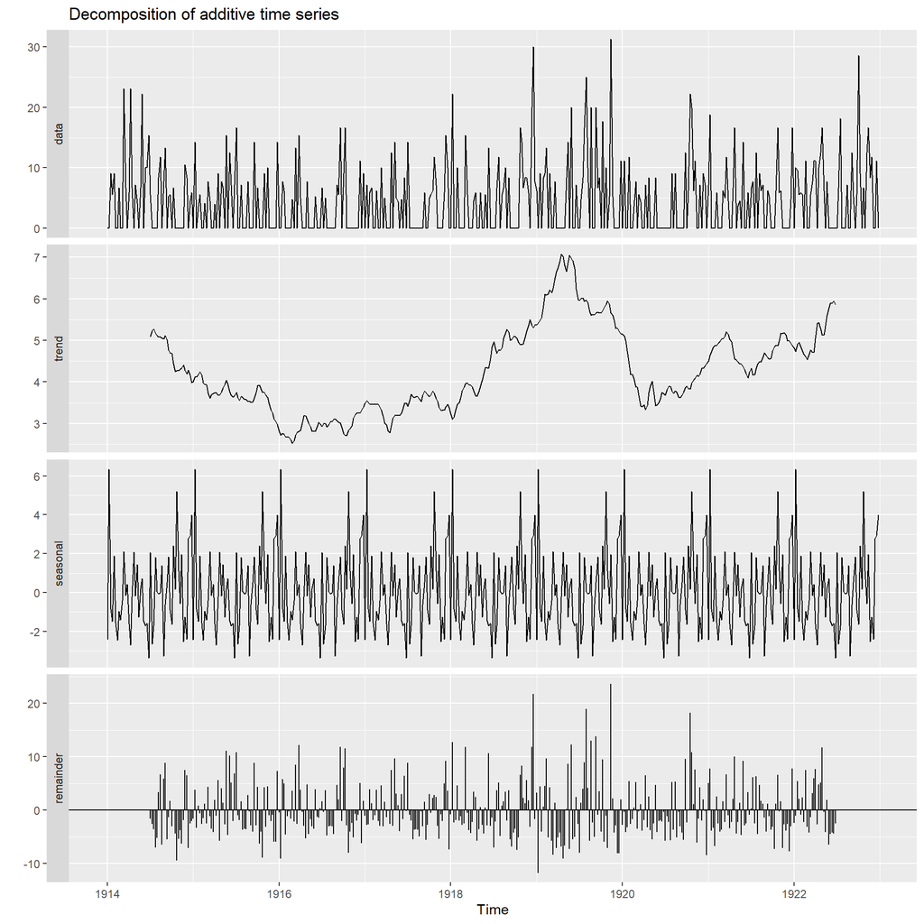

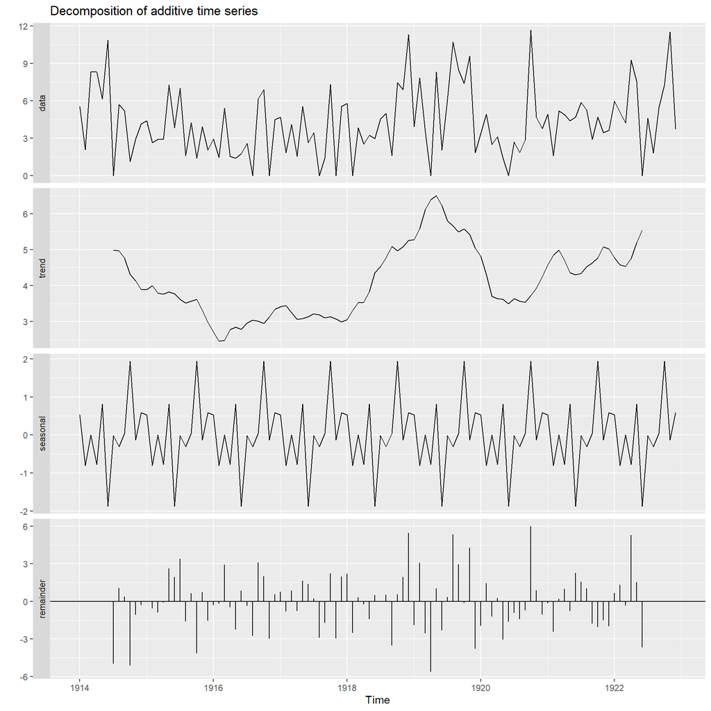

## unadjusted

The quantile regression does not provide any further information. The results are similar when using the quantile and linear regressions. No significant differences between the quantiles are found for the years 1918 and 1919.

### Quantile regression

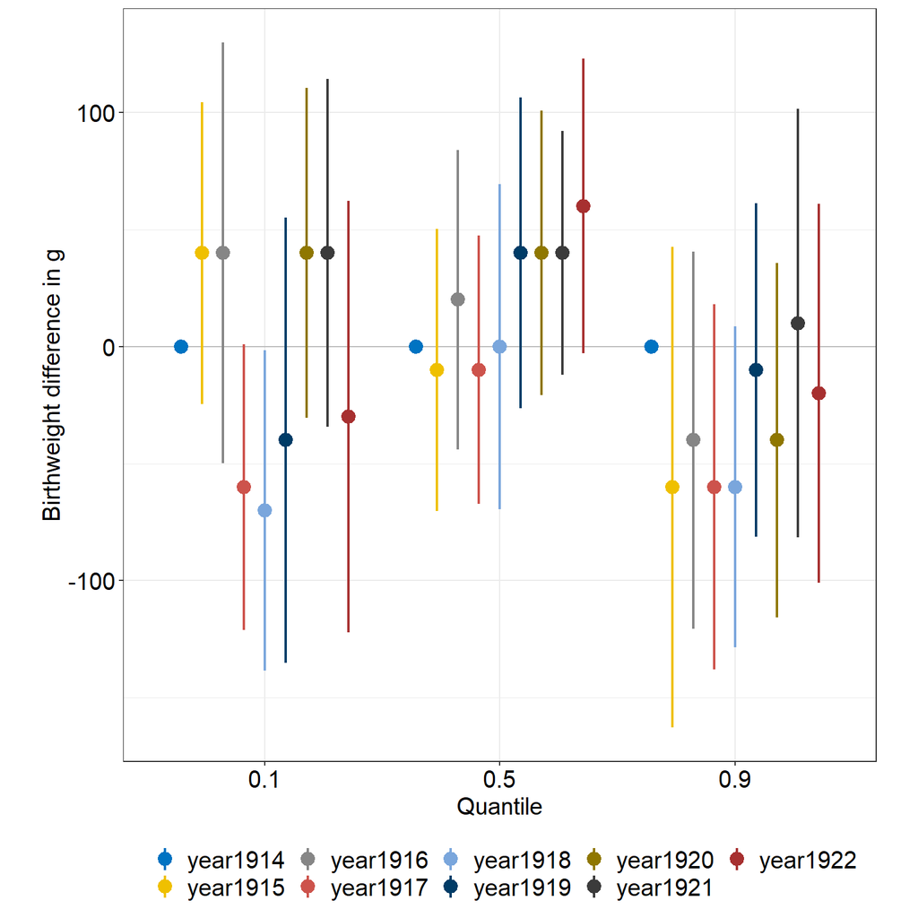

### Year

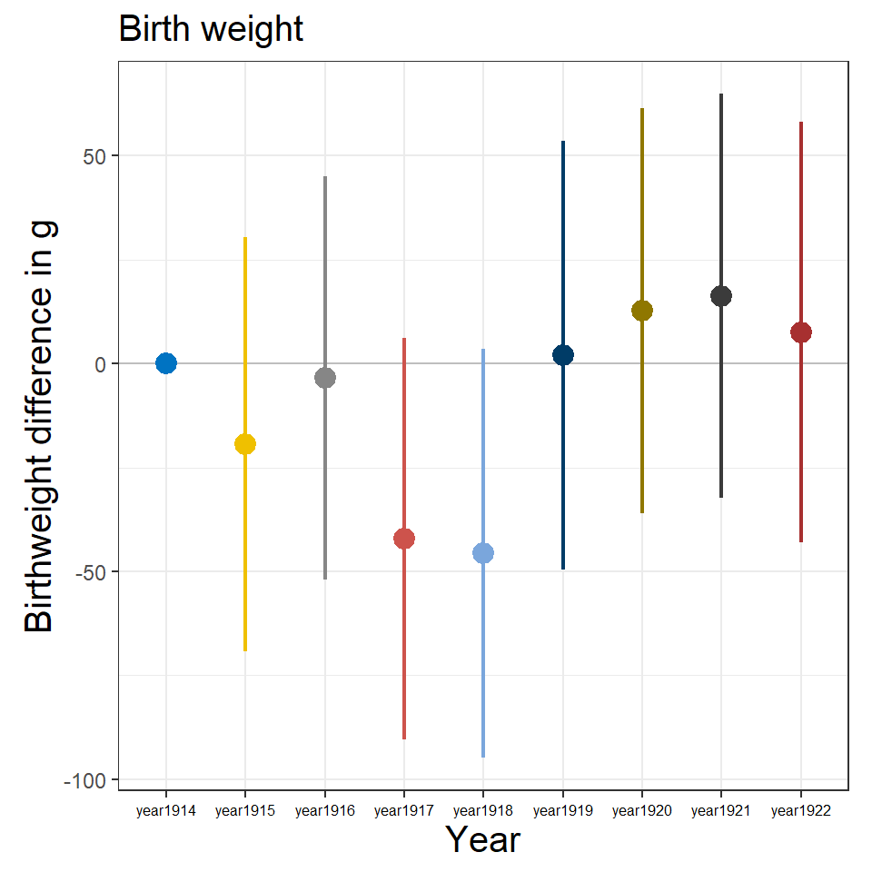

### Sex

```
##
## Call:
## lm(formula = formula, data = datared)
##
## Residuals:
##      Min       1Q   Median       3Q      Max
## -1739.03  -305.77     0.97   304.23  2010.97
##
## Coefficients:
##             Estimate Std. Error t value Pr(>|t|)
## (Intercept) 3249.025      8.189  396.74   <2e-16 ***
## boy0        -143.260     11.817  -12.12   <2e-16 ***
## ---
## Signif. codes:  0 '***' 0.001 '**' 0.01 '*' 0.05 '.' 0.1 ' ' 1
##
## Residual standard error: 479.3 on 6588 degrees of freedom
##   (1 Beobachtung als fehlend gelöscht)
## Multiple R-squared:  0.02182,    Adjusted R-squared:  0.02167
## F-statistic:   147 on 1 and 6588 DF,  p-value: < 2.2e-16
```

### Gestational age

```
##
## Call:
## lm(formula = formula, data = datared)
##
## Residuals:
##      Min       1Q   Median       3Q      Max
## -1653.69  -303.69   -13.69   296.31  2278.01
##
## Coefficients:
##                 Estimate Std. Error t value Pr(>|t|)
## (Intercept)     3233.686      6.235  518.66   <2e-16 ***
## Gest_groupearly -361.696     16.210  -22.31   <2e-16 ***
## ---
## Signif. codes:  0 '***' 0.001 '**' 0.01 '*' 0.05 '.' 0.1 ' ' 1
##
## Residual standard error: 467.2 on 6589 degrees of freedom
## Multiple R-squared:  0.07025,    Adjusted R-squared:  0.07011
## F-statistic: 497.9 on 1 and 6589 DF,  p-value: < 2.2e-16
```

### Birth month

```
##
## Call:
## lm(formula = formula, data = datared)
##
## Residuals:
##      Min       1Q   Median       3Q      Max
## -1684.89  -315.47     0.42   310.75  2077.76
##
## Coefficients:
##               Estimate Std. Error t value Pr(>|t|)
## (Intercept)   3182.238     20.585 154.592   <2e-16 ***
## birth_month2   -33.065     29.327  -1.127    0.260
## birth_month3   -12.902     28.435  -0.454    0.650
## birth_month4   -32.655     29.138  -1.121    0.262
## birth_month5   -15.707     28.807  -0.545    0.586
## birth_month6     2.676     29.482   0.091    0.928
## birth_month7   -15.513     28.894  -0.537    0.591
## birth_month8    13.781     29.583   0.466    0.641
## birth_month9    10.098     29.164   0.346    0.729
## birth_month10   25.592     28.969   0.883    0.377
## birth_month11   34.800     29.569   1.177    0.239
## birth_month12    2.653     29.809   0.089    0.929
## ---
## Signif. codes:  0 '***' 0.001 '**' 0.01 '*' 0.05 '.' 0.1 ' ' 1
##
## Residual standard error: 484.5 on 6579 degrees of freedom
## Multiple R-squared:  0.001741,   Adjusted R-squared:  7.204e-05
## F-statistic: 1.043 on 11 and 6579 DF,  p-value: 0.4046
```

### Maternal age

```
##
## Call:
## lm(formula = formula, data = datared)
##
## Residuals:
##      Min       1Q   Median       3Q      Max
## -1764.38  -304.64     3.27   305.47  2039.90
##
## Coefficients:
##              Estimate Std. Error t value Pr(>|t|)
## (Intercept) 2936.0231    26.6231 110.281   <2e-16 ***
## matage         8.8773     0.9437   9.407   <2e-16 ***
## ---
## Signif. codes:  0 '***' 0.001 '**' 0.01 '*' 0.05 '.' 0.1 ' ' 1
##
## Residual standard error: 481.3 on 6589 degrees of freedom
## Multiple R-squared:  0.01325,    Adjusted R-squared:  0.0131
## F-statistic: 88.49 on 1 and 6589 DF,  p-value: < 2.2e-16
```

### Married

```
##
## Call:
## lm(formula = formula, data = datared)
##
## Residuals:
##      Min       1Q   Median       3Q      Max
## -1675.89  -305.89    -0.16   306.97  2044.11
##
## Coefficients:
##             Estimate Std. Error t value Pr(>|t|)
## (Intercept)  3215.89       6.90  466.09   <2e-16 ***
## married0     -135.73      13.45  -10.09   <2e-16 ***
## ---
## Signif. codes:  0 '***' 0.001 '**' 0.01 '*' 0.05 '.' 0.1 ' ' 1
##
## Residual standard error: 480.9 on 6589 degrees of freedom
## Multiple R-squared:  0.01522,    Adjusted R-squared:  0.01507
## F-statistic: 101.8 on 1 and 6589 DF,  p-value: < 2.2e-16
```

### City

```
##
## Call:
## lm(formula = formula, data = datared)
##
## Residuals:
##      Min       1Q   Median       3Q      Max
## -1664.63  -314.63     2.33   305.37  2095.37
##
## Coefficients:
##             Estimate Std. Error t value Pr(>|t|)
## (Intercept) 3164.631      8.199 385.991  < 2e-16 ***
## city0         33.039     11.951   2.765  0.00572 **
## ---
## Signif. codes:  0 '***' 0.001 '**' 0.01 '*' 0.05 '.' 0.1 ' ' 1
##
## Residual standard error: 484.3 on 6589 degrees of freedom
## Multiple R-squared:  0.001159,   Adjusted R-squared:  0.001007
## F-statistic: 7.643 on 1 and 6589 DF,  p-value: 0.005716
```

### Insurance

```
##
## Call:
## lm(formula = formula, data = datared)
##
## Residuals:
##      Min       1Q   Median       3Q      Max
## -1674.35  -314.35     5.65   305.65  1975.65
##
## Coefficients:
##             Estimate Std. Error t value Pr(>|t|)
## (Intercept)  3174.35       6.11 519.552  < 2e-16 ***
## insurance1    120.44      27.77   4.337 1.47e-05 ***
## ---
## Signif. codes:  0 '***' 0.001 '**' 0.01 '*' 0.05 '.' 0.1 ' ' 1
##
## Residual standard error: 483.9 on 6589 degrees of freedom
## Multiple R-squared:  0.002846,   Adjusted R-squared:  0.002695
## F-statistic: 18.81 on 1 and 6589 DF,  p-value: 1.466e-05
```

### Flu Boxplot

Data range from 09.07.1918 – 02.02.1919  
Only multiple==0, matage > 50 and matage <14 were excluded

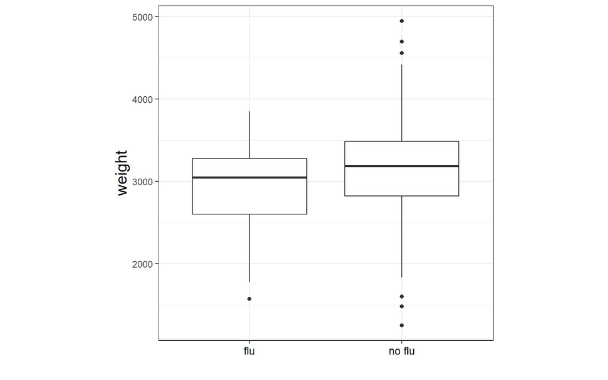

### Flu intensity

```
##
## Call:
## lm(formula = weight ~ Flu_intensity_all, data = datared)
##
## Residuals:
##     Min      1Q  Median      3Q     Max
## -1679.7  -309.7     0.3   310.3  2080.3
##
## Coefficients:
##                   Estimate Std. Error t value Pr(>|t|)
## (Intercept)       3179.702      6.282 506.147   <2e-16 ***
## Flu_intensity_all    8.092     33.106   0.244    0.807
## ---
## Signif. codes:  0 '***' 0.001 '**' 0.01 '*' 0.05 '.' 0.1 ' ' 1
##
## Residual standard error: 484.6 on 6589 degrees of freedom
## Multiple R-squared:  9.067e-06,  Adjusted R-squared:  -0.0001427
## F-statistic: 0.05975 on 1 and 6589 DF,  p-value: 0.8069
```

### Flu intensity - Quantile Regression

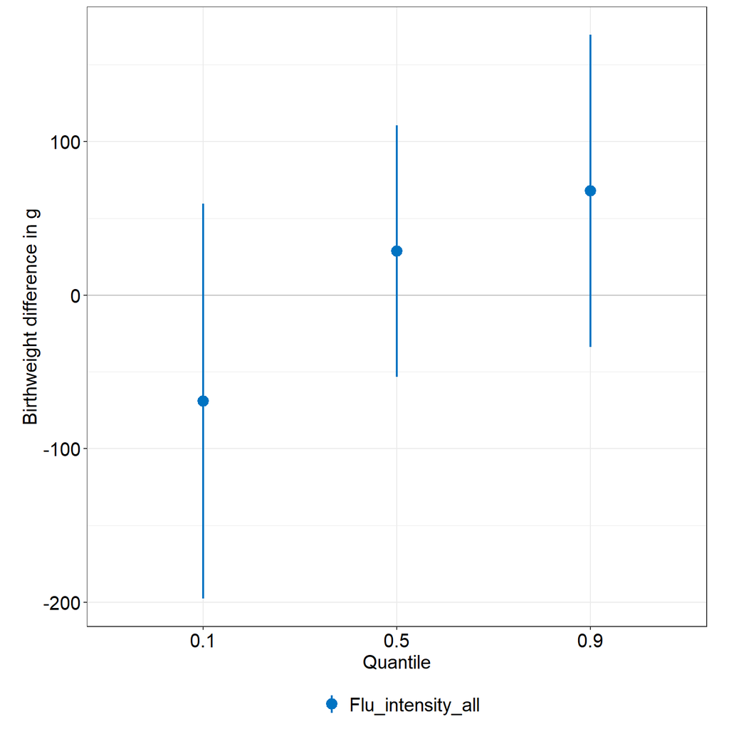

## adjusted

### Quantile regression

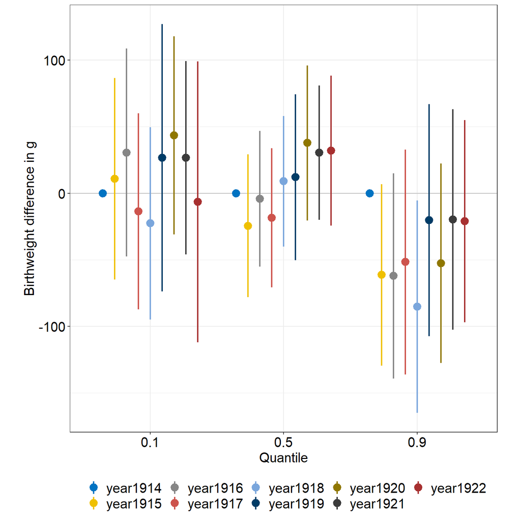

### Year

```
##
## Call:
## lm(formula = weight ~ year + boy + parity + Gest_group + birth_month +
##     matage + married + city + insurance, data = datared)
##
## Residuals:
##      Min       1Q   Median       3Q      Max
## -1820.61  -290.20    -3.04   284.67  2042.84
##
## Coefficients:
##                 Estimate Std. Error t value Pr(>|t|)
## (Intercept)     3244.243     38.991  83.204  < 2e-16 ***
## year1915         -17.862     23.718  -0.753   0.4514
## year1916          -6.207     23.124  -0.268   0.7884
## year1917         -27.765     22.974  -1.209   0.2269
## year1918         -24.675     23.418  -1.054   0.2921
## year1919         -10.491     24.511  -0.428   0.6686
## year1920          18.621     23.157   0.804   0.4213
## year1921          17.038     23.201   0.734   0.4627
## year1922          12.805     24.095   0.531   0.5951
## boy0            -144.834     11.130 -13.013  < 2e-16 ***
## parity2          132.230     15.373   8.602  < 2e-16 ***
## parity3          186.988     19.393   9.642  < 2e-16 ***
## parity>=4        237.619     18.219  13.043  < 2e-16 ***
## Gest_groupearly -351.840     15.765 -22.318  < 2e-16 ***
## birth_month2     -43.779     27.299  -1.604   0.1088
## birth_month3      -7.497     26.459  -0.283   0.7769
## birth_month4     -10.628     27.106  -0.392   0.6950
## birth_month5     -18.923     26.790  -0.706   0.4800
## birth_month6      -5.667     27.417  -0.207   0.8363
## birth_month7     -16.571     26.887  -0.616   0.5377
## birth_month8       4.766     27.544   0.173   0.8626
## birth_month9      -5.784     27.171  -0.213   0.8314
## birth_month10     21.219     26.976   0.787   0.4316
## birth_month11     50.721     27.553   1.841   0.0657 .
## birth_month12     -9.163     27.749  -0.330   0.7413
## matage            -1.698      1.116  -1.522   0.1281
## married0         -30.697     14.058  -2.184   0.0290 *
## city0             16.585     11.257   1.473   0.1407
## insurance1       144.129     26.625   5.413 6.41e-08 ***
## ---
## Signif. codes:  0 '***' 0.001 '**' 0.01 '*' 0.05 '.' 0.1 ' ' 1
##
## Residual standard error: 450 on 6545 degrees of freedom
##   (17 Beobachtungen als fehlend gelöscht)
## Multiple R-squared:  0.141,  Adjusted R-squared:  0.1373
## F-statistic: 38.37 on 28 and 6545 DF,  p-value: < 2.2e-16
```

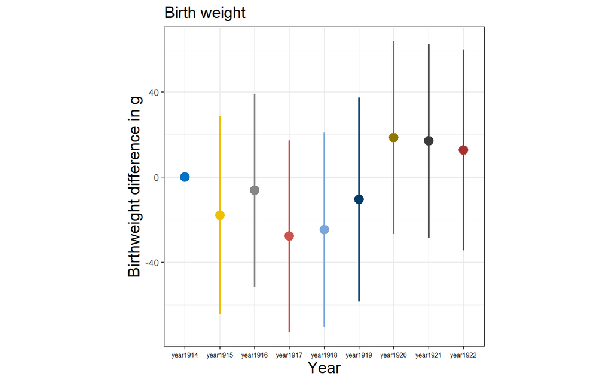

### Flu Intensity

```
##
## Call:
## lm(formula = weight ~ boy + parity + Gest_group + birth_month +
##     matage + married + city + insurance + Flu_intensity_all,
##     data = datared)
##
## Residuals:
##      Min       1Q   Median       3Q      Max
## -1803.32  -288.80    -2.88   282.63  2067.68
##
## Coefficients:
##                   Estimate Std. Error t value Pr(>|t|)
## (Intercept)       3240.926     35.832  90.447  < 2e-16 ***
## boy0              -145.199     11.128 -13.049  < 2e-16 ***
## parity2            131.030     15.345   8.539  < 2e-16 ***
## parity3            183.647     19.349   9.492  < 2e-16 ***
## parity>=4          235.554     18.190  12.950  < 2e-16 ***
## Gest_groupearly   -354.220     15.741 -22.503  < 2e-16 ***
## birth_month2       -43.439     27.288  -1.592   0.1115
## birth_month3        -7.595     26.458  -0.287   0.7741
## birth_month4       -12.277     27.100  -0.453   0.6506
## birth_month5       -18.923     26.774  -0.707   0.4797
## birth_month6        -5.996     27.406  -0.219   0.8268
## birth_month7       -15.887     26.869  -0.591   0.5543
## birth_month8         3.499     27.531   0.127   0.8989
## birth_month9        -6.050     27.160  -0.223   0.8237
## birth_month10       19.464     26.956   0.722   0.4703
## birth_month11       50.508     27.530   1.835   0.0666 .
## birth_month12       -9.816     27.727  -0.354   0.7233
## matage              -1.649      1.115  -1.478   0.1394
## married0           -31.355     14.041  -2.233   0.0256 *
## city0               16.861     11.253   1.498   0.1341
## insurance1         146.917     26.576   5.528 3.36e-08 ***
## Flu_intensity_all   -5.435     30.871  -0.176   0.8602
## ---
## Signif. codes:  0 '***' 0.001 '**' 0.01 '*' 0.05 '.' 0.1 ' ' 1
##
## Residual standard error: 450.1 on 6552 degrees of freedom
##   (17 Beobachtungen als fehlend gelöscht)
## Multiple R-squared:  0.1398, Adjusted R-squared:  0.137
## F-statistic: 50.71 on 21 and 6552 DF,  p-value: < 2.2e-16
```

### Flu Intensity - Quantile Regression

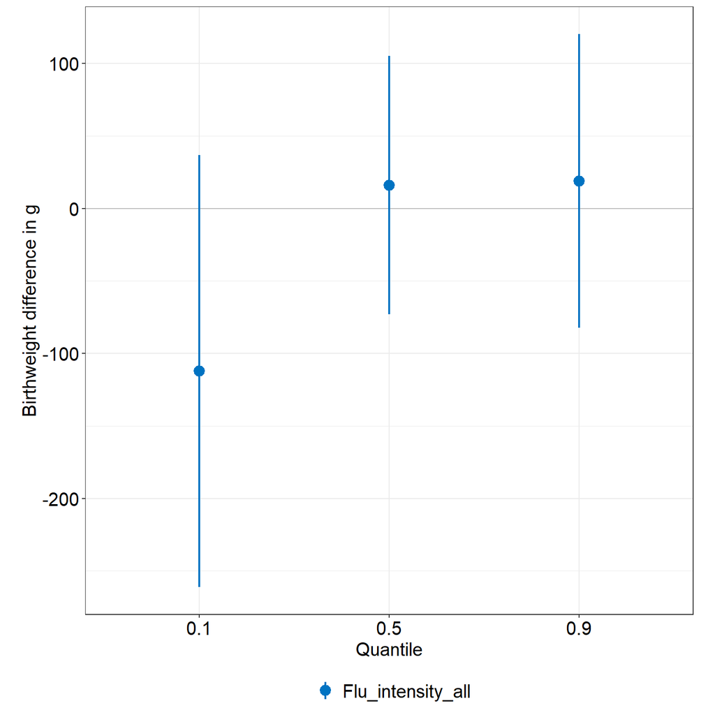

# Gestational age

| year | normal | early | total | perc_early |
| --- | --- | --- | --- | --- |
| 1914 | 647 | 105 | 752 | 13.96 |
| 1915 | 601 | 99 | 700 | 14.14 |
| 1916 | 662 | 113 | 775 | 14.58 |
| 1917 | 642 | 154 | 796 | 19.35 |
| 1918 | 611 | 131 | 742 | 17.65 |
| 1919 | 538 | 79 | 617 | 12.80 |
| 1920 | 675 | 98 | 773 | 12.68 |
| 1921 | 668 | 104 | 772 | 13.47 |
| 1922 | 572 | 92 | 664 | 13.86 |

I did the analysis with and without stillborns -> similar results. The results are shown with data without Stillborn. High multicollinearity between year and exposure sum and year and flu intensity. Therefor only one variable is used.

## unadjusted

### Year

```
##
## Call:
## glm(formula = formula, family = binomial(link = "logit"), data = datared_still_n)
##
## Deviance Residuals:
##     Min       1Q   Median       3Q      Max
## -0.6558  -0.5614  -0.5462  -0.5207   2.0324
##
## Coefficients:
##              Estimate Std. Error z value Pr(>|z|)
## (Intercept) -1.818386   0.105211 -17.283  < 2e-16 ***
## year1915     0.014911   0.151110   0.099  0.92140
## year1916     0.050508   0.146388   0.345  0.73007
## year1917     0.390750   0.138277   2.826  0.00472 **
## year1918     0.278486   0.142617   1.953  0.05086 .
## year1919    -0.100025   0.159957  -0.625  0.53176
## year1920    -0.111359   0.150847  -0.738  0.46038
## year1921    -0.041511   0.148935  -0.279  0.78046
## year1922    -0.008964   0.153906  -0.058  0.95355
## ---
## Signif. codes:  0 '***' 0.001 '**' 0.01 '*' 0.05 '.' 0.1 ' ' 1
##
## (Dispersion parameter for binomial family taken to be 1)
##
##     Null deviance: 5524.6  on 6590  degrees of freedom
## Residual deviance: 5500.7  on 6582  degrees of freedom
## AIC: 5518.7
##
## Number of Fisher Scoring iterations: 4
```

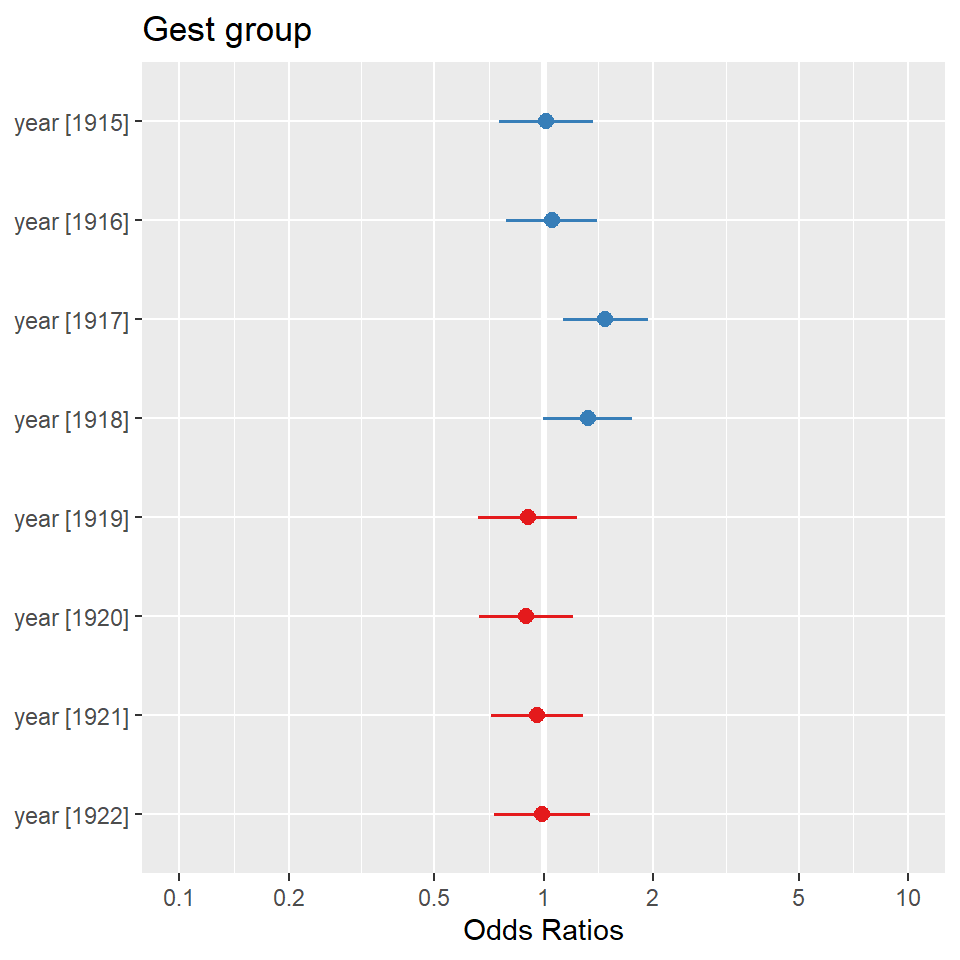

### Flu intensity

```
##
## Call:
## glm(formula = formula, family = binomial(link = "logit"), data = datared_still_n)
##
## Deviance Residuals:
##     Min       1Q   Median       3Q      Max
## -0.5713  -0.5713  -0.5713  -0.5594   2.1058
##
## Coefficients:
##                   Estimate Std. Error z value Pr(>|z|)
## (Intercept)       -1.73007    0.03629 -47.674   <2e-16 ***
## Flu_intensity_all -0.37946    0.20857  -1.819   0.0689 .
## ---
## Signif. codes:  0 '***' 0.001 '**' 0.01 '*' 0.05 '.' 0.1 ' ' 1
##
## (Dispersion parameter for binomial family taken to be 1)
##
##     Null deviance: 5524.6  on 6590  degrees of freedom
## Residual deviance: 5521.1  on 6589  degrees of freedom
## AIC: 5525.1
##
## Number of Fisher Scoring iterations: 4
```

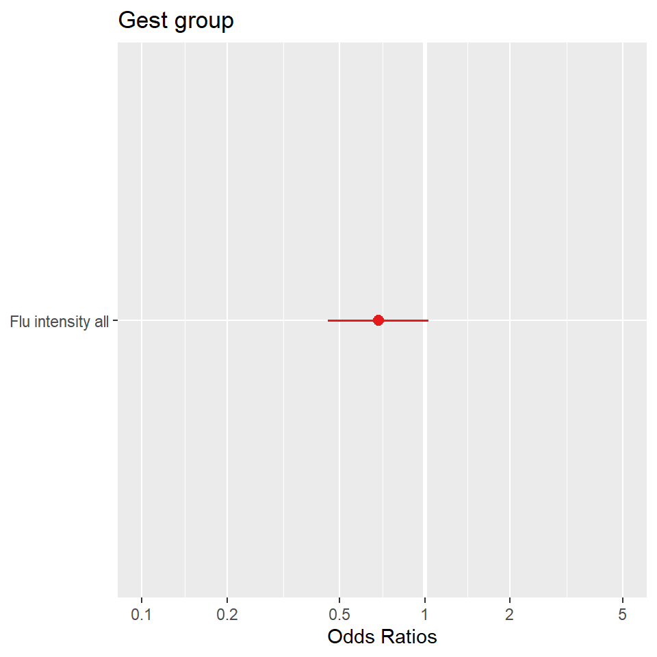

## adjusted

### Quantile regression

[figure not shown]

### Year

```
##
## Call:
## glm(formula = formula, family = binomial(link = "logit"), data = datared_still_n)
##
## Deviance Residuals:
##     Min       1Q   Median       3Q      Max
## -0.9057  -0.5985  -0.5271  -0.4575   2.3992
##
## Coefficients:
##                Estimate Std. Error z value Pr(>|z|)
## (Intercept)   -1.438230   0.245946  -5.848 4.98e-09 ***
## year1915       0.023578   0.152602   0.155 0.877210
## year1916       0.055925   0.148078   0.378 0.705672
## year1917       0.420728   0.139864   3.008 0.002629 **
## year1918       0.282015   0.144545   1.951 0.051050 .
## year1919      -0.102179   0.161434  -0.633 0.526768
## year1920      -0.101933   0.152412  -0.669 0.503625
## year1921      -0.050264   0.151313  -0.332 0.739748
## year1922       0.007386   0.155695   0.047 0.962163
## boy0          -0.119559   0.070419  -1.698 0.089542 .
## parity2       -0.149977   0.099008  -1.515 0.129823
## parity3       -0.271344   0.131020  -2.071 0.038358 *
## parity>=4      0.100222   0.115047   0.871 0.383679
## birth_month2  -0.302293   0.177079  -1.707 0.087802 .
## birth_month3  -0.018853   0.162446  -0.116 0.907608
## birth_month4   0.218253   0.160107   1.363 0.172828
## birth_month5  -0.118845   0.166675  -0.713 0.475824
## birth_month6   0.057667   0.165521   0.348 0.727542
## birth_month7  -0.074597   0.166753  -0.447 0.654623
## birth_month8  -0.226691   0.176085  -1.287 0.197958
## birth_month9  -0.419248   0.180439  -2.323 0.020153 *
## birth_month10 -0.342159   0.175558  -1.949 0.051298 .
## birth_month11  0.216193   0.162689   1.329 0.183892
## birth_month12 -0.180461   0.175216  -1.030 0.303041
## city0         -0.098283   0.071146  -1.381 0.167149
## matage        -0.009083   0.007168  -1.267 0.205096
## married0       0.301776   0.085301   3.538 0.000404 ***
## insurance1    -0.149592   0.182410  -0.820 0.412166
## ---
## Signif. codes:  0 '***' 0.001 '**' 0.01 '*' 0.05 '.' 0.1 ' ' 1
##
## (Dispersion parameter for binomial family taken to be 1)
##
##     Null deviance: 5501.6  on 6573  degrees of freedom
## Residual deviance: 5407.2  on 6546  degrees of freedom
##   (17 Beobachtungen als fehlend gelöscht)
## AIC: 5463.2
##
## Number of Fisher Scoring iterations: 4
```

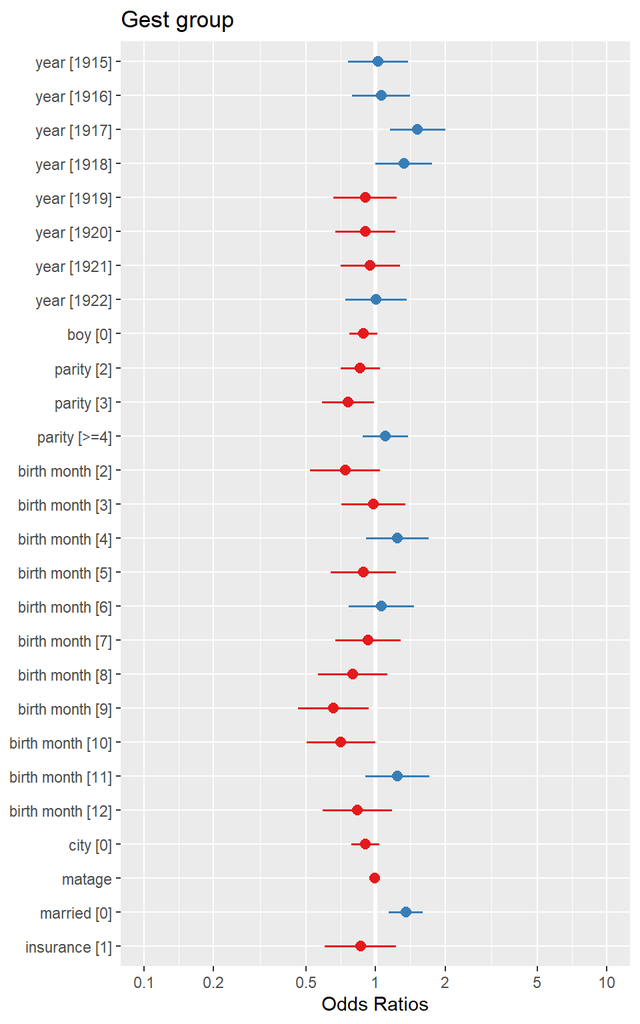

### Flu intensity

```
##
## Call:
## glm(formula = formula, family = binomial(link = "logit"), data = datared_still_n)
##
## Deviance Residuals:
##     Min       1Q   Median       3Q      Max
## -0.8028  -0.5981  -0.5343  -0.4692   2.3425
##
## Coefficients:
##                    Estimate Std. Error z value Pr(>|z|)
## (Intercept)       -1.341299   0.223798  -5.993 2.06e-09 ***
## boy0              -0.114407   0.070262  -1.628 0.103466
## parity2           -0.150364   0.098573  -1.525 0.127157
## parity3           -0.250206   0.130601  -1.916 0.055390 .
## parity>=4          0.106850   0.114476   0.933 0.350619
## birth_month2      -0.310869   0.176712  -1.759 0.078547 .
## birth_month3      -0.016526   0.162163  -0.102 0.918830
## birth_month4       0.233092   0.159730   1.459 0.144486
## birth_month5      -0.111022   0.166263  -0.668 0.504295
## birth_month6       0.070483   0.165073   0.427 0.669396
## birth_month7      -0.084987   0.166359  -0.511 0.609444
## birth_month8      -0.220382   0.175707  -1.254 0.209748
## birth_month9      -0.422706   0.180064  -2.348 0.018898 *
## birth_month10     -0.338929   0.175067  -1.936 0.052869 .
## birth_month11      0.199257   0.162184   1.229 0.219226
## birth_month12     -0.174739   0.174699  -1.000 0.317201
## city0             -0.098581   0.071004  -1.388 0.165019
## matage            -0.009276   0.007131  -1.301 0.193336
## married0           0.298960   0.084996   3.517 0.000436 ***
## insurance1        -0.162816   0.181791  -0.896 0.370454
## Flu_intensity_all -0.408992   0.207864  -1.968 0.049115 *
## ---
## Signif. codes:  0 '***' 0.001 '**' 0.01 '*' 0.05 '.' 0.1 ' ' 1
##
## (Dispersion parameter for binomial family taken to be 1)
##
##     Null deviance: 5501.6  on 6573  degrees of freedom
## Residual deviance: 5428.5  on 6553  degrees of freedom
##   (17 Beobachtungen als fehlend gelöscht)
## AIC: 5470.5
##
## Number of Fisher Scoring iterations: 4
```

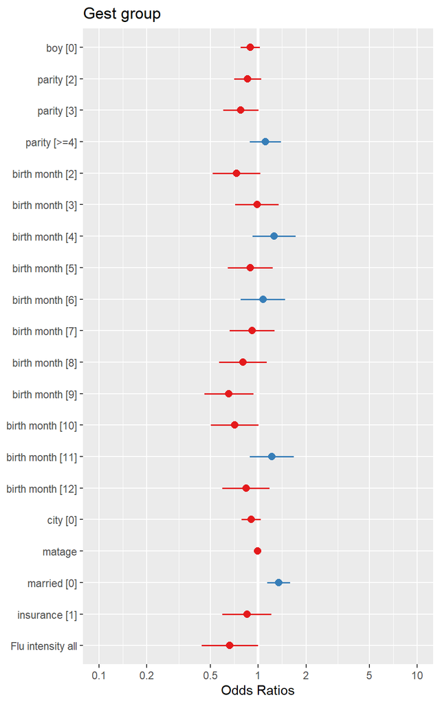

# Stillborn

Data Bern

| year | alive | stillborn | perc_stillborn | alive_bfs | stillborn_bfs | perc_stillborn_bfs | Perc_diff |
| --- | --- | --- | --- | --- | --- | --- | --- |
| 1912 | 617 | 27 | 4.19 | 92196 | 2975 | 3.13 | -1.06 |
| 1913 | 718 | 28 | 3.75 | 89757 | 2846 | 3.07 | -0.68 |
| 1914 | 752 | 37 | 4.69 | 87330 | 2798 | 3.10 | -1.59 |
| 1915 | 700 | 26 | 3.58 | 75545 | 2386 | 3.06 | -0.52 |
| 1916 | 775 | 23 | 2.88 | 73660 | 2225 | 2.93 | 0.05 |
| 1917 | 796 | 28 | 3.40 | 72065 | 2060 | 2.78 | -0.62 |
| 1918 | 742 | 35 | 4.50 | 72658 | 2226 | 2.97 | -1.53 |
| 1919 | 617 | 39 | 5.95 | 72125 | 2080 | 2.80 | -3.15 |
| 1920 | 773 | 28 | 3.50 | 81190 | 2433 | 2.91 | -0.59 |
| 1921 | 772 | 35 | 4.34 | 80808 | 2365 | 2.84 | -1.50 |
| 1922 | 664 | 38 | 5.41 | 76290 | 2246 | 2.86 | -2.55 |

High multicollinearity between year and exposure sum and year and flu intensity. Therefor only one variable is used.

## unadjusted

### Year

```
##
## Call:
## glm(formula = formula, family = binomial(link = "logit"), data = datared)
##
## Deviance Residuals:
##     Min       1Q   Median       3Q      Max
## -0.3501  -0.3099  -0.2978  -0.2630   2.6633
##
## Coefficients:
##             Estimate Std. Error z value Pr(>|z|)
## (Intercept) -3.01182    0.16839 -17.885   <2e-16 ***
## year1915    -0.28117    0.26124  -1.076   0.2818
## year1916    -0.50555    0.27042  -1.870   0.0615 .
## year1917    -0.33558    0.25559  -1.313   0.1892
## year1918    -0.04218    0.24140  -0.175   0.8613
## year1919     0.25051    0.23584   1.062   0.2881
## year1920    -0.30626    0.25567  -1.198   0.2310
## year1921    -0.08182    0.24130  -0.339   0.7346
## year1922     0.15112    0.23702   0.638   0.5237
## ---
## Signif. codes:  0 '***' 0.001 '**' 0.01 '*' 0.05 '.' 0.1 ' ' 1
##
## (Dispersion parameter for binomial family taken to be 1)
##
##     Null deviance: 2397.9  on 6879  degrees of freedom
## Residual deviance: 2383.4  on 6871  degrees of freedom
## AIC: 2401.4
##
## Number of Fisher Scoring iterations: 6
```

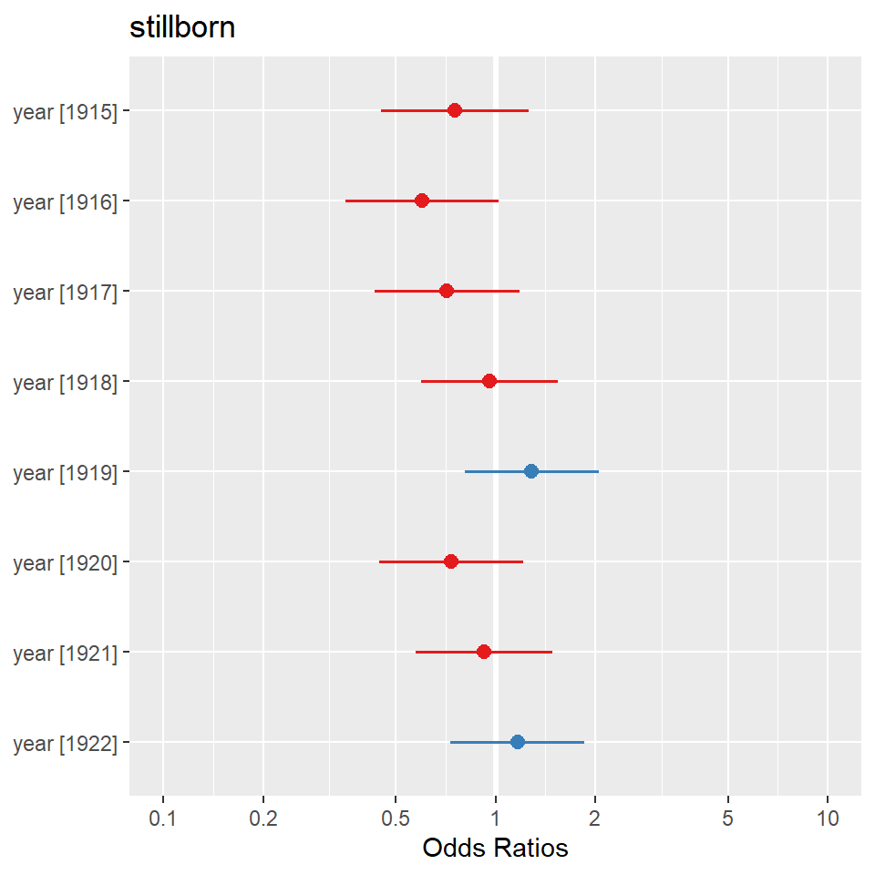

### Flu Intensity

```
##
## Call:
## glm(formula = formula, family = binomial(link = "logit"), data = datared)
##
## Deviance Residuals:
##     Min       1Q   Median       3Q      Max
## -0.3956  -0.2860  -0.2860  -0.2860   2.5365
##
## Coefficients:
##                   Estimate Std. Error z value Pr(>|z|)
## (Intercept)       -3.17590    0.06459 -49.174   <2e-16 ***
## Flu_intensity_all  0.68080    0.27942   2.436   0.0148 *
## ---
## Signif. codes:  0 '***' 0.001 '**' 0.01 '*' 0.05 '.' 0.1 ' ' 1
##
## (Dispersion parameter for binomial family taken to be 1)
##
##     Null deviance: 2397.9  on 6879  degrees of freedom
## Residual deviance: 2392.6  on 6878  degrees of freedom
## AIC: 2396.6
##
## Number of Fisher Scoring iterations: 6
```

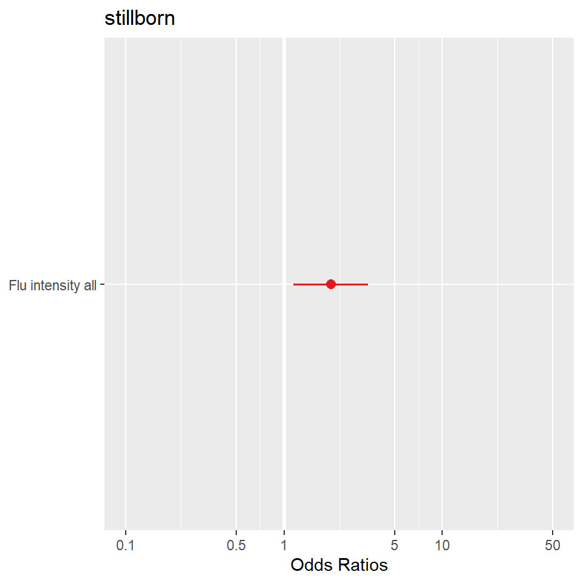

## adjusted

```
##
## Call:
## glm(formula = formula, family = binomial(link = "logit"), data = datared)
##
## Deviance Residuals:
##     Min       1Q   Median       3Q      Max
## -0.7008  -0.3138  -0.2524  -0.2108   3.0324
##
## Coefficients:
##             Estimate Std. Error z value Pr(>|z|)
## (Intercept) -5.29316    0.38399 -13.785  < 2e-16 ***
## year1915    -0.29885    0.26520  -1.127   0.2598
## year1916    -0.53507    0.27768  -1.927   0.0540 .
## year1917    -0.33362    0.25932  -1.286   0.1983
## year1918    -0.05358    0.24907  -0.215   0.8297
## year1919     0.24609    0.23999   1.025   0.3052
## year1920    -0.26893    0.25977  -1.035   0.3005
## year1921    -0.09753    0.24574  -0.397   0.6915
## year1922     0.14631    0.24308   0.602   0.5472
## boy0        -0.03234    0.12264  -0.264   0.7920
## parity2     -0.04370    0.18345  -0.238   0.8117
## parity3     -0.47704    0.25478  -1.872   0.0612 .
## parity>=4    0.15665    0.18335   0.854   0.3929
## birth_month  0.01394    0.01791   0.778   0.4363
## matage       0.07118    0.01096   6.492 8.47e-11 ***
## married0     0.05985    0.16578   0.361   0.7181
## city0        0.23996    0.12524   1.916   0.0554 .
## insurance1  -0.32738    0.32149  -1.018   0.3085
## ---
## Signif. codes:  0 '***' 0.001 '**' 0.01 '*' 0.05 '.' 0.1 ' ' 1
##
## (Dispersion parameter for binomial family taken to be 1)
##
##     Null deviance: 2364.7  on 6857  degrees of freedom
## Residual deviance: 2259.8  on 6840  degrees of freedom
##   (22 Beobachtungen als fehlend gelöscht)
## AIC: 2295.8
##
## Number of Fisher Scoring iterations: 6
```

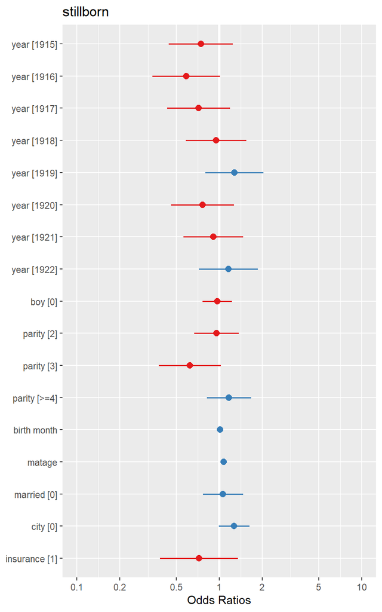

### Flu intensity

```
##
## Call:
## glm(formula = formula, family = binomial(link = "logit"), data = datared)
##
## Deviance Residuals:
##     Min       1Q   Median       3Q      Max
## -0.7142  -0.3141  -0.2513  -0.2154   2.9113
##
## Coefficients:
##                   Estimate Std. Error z value Pr(>|z|)
## (Intercept)       -5.46390    0.34784 -15.708  < 2e-16 ***
## boy0              -0.03657    0.12251  -0.298   0.7653
## parity2           -0.05707    0.18315  -0.312   0.7554
## parity3           -0.49656    0.25450  -1.951   0.0510 .
## parity>=4          0.14502    0.18344   0.791   0.4292
## birth_month        0.01733    0.01790   0.968   0.3331
## matage             0.07067    0.01096   6.449 1.12e-10 ***
## married0           0.05792    0.16580   0.349   0.7269
## city0              0.24681    0.12496   1.975   0.0483 *
## insurance1        -0.29802    0.32095  -0.929   0.3531
## Flu_intensity_all  0.69036    0.28587   2.415   0.0157 *
## ---
## Signif. codes:  0 '***' 0.001 '**' 0.01 '*' 0.05 '.' 0.1 ' ' 1
##
## (Dispersion parameter for binomial family taken to be 1)
##
##     Null deviance: 2364.7  on 6857  degrees of freedom
## Residual deviance: 2268.6  on 6847  degrees of freedom
##   (22 Beobachtungen als fehlend gelöscht)
## AIC: 2290.6
##
## Number of Fisher Scoring iterations: 6
```

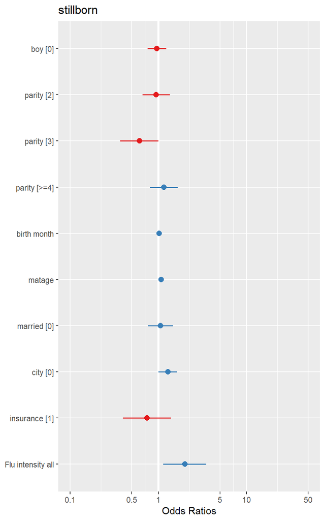